# Tidying data up

# Tidy Data

As mentioned in other documents in this module, tidy data follows three rules:

- Each variable must have its own column.
- Each observation must have its own row.
- Each value must have its own cell.

R likes vectorized data, and having one column (i.e., a vector) per variable in your data makes data manipulation much easier. Also, as with your coding and documentation, choosing one consistent way of doing things (and sticking to it) helps to make your data analysis more robust. Choosing one way to represent data fits into this pattern of making everything consistent.

We will be using a famous and widely used data set (i.e., gapminder) to demonstrate how easy working with tidy data can be with `tidyverse`.

```r
# load libraries
library(tidyverse)
library(gapminder)

# inspect gaminder data
head(gapminder)
```

| country | continent | year | lifeExp | pop | gdpPercap |
| --- | --- | --- | --- | --- | --- |
| Afghanistan | Asia | 1952 | 28.801 | 8425333 | 779.4453 |
| Afghanistan | Asia | 1957 | 30.332 | 9240934 | 820.8530 |
| Afghanistan | Asia | 1962 | 31.997 | 10267083 | 853.1007 |
| Afghanistan | Asia | 1967 | 34.020 | 11537966 | 836.1971 |
| Afghanistan | Asia | 1972 | 36.088 | 13079460 | 739.9811 |
| Afghanistan | Asia | 1977 | 38.438 | 14880372 | 786.1134 |

We can create new variables (i.e., columns) based on our existing variables by calling each variable by its name. For example, let’s calculate Gross domestic product (GDP) based on population (i.e., `pop`) and GDP per capita (i.e., `gdpPercap`).

```r
# create total_gdp using mutate() based on gdpPercap and pop
gapminder_with_gdp <- gapminder %>%
  mutate(total_gdp = gdpPercap * pop)

# inspect data
gapminder_with_gdp %>%
  head()
```

```
## # A tibble: 6 × 7
##   country     continent  year lifeExp      pop gdpPercap    total_gdp
##   <fct>       <fct>     <int>   <dbl>    <int>     <dbl>        <dbl>
## 1 Afghanistan Asia       1952    28.8  8425333      779.  6567086330.
## 2 Afghanistan Asia       1957    30.3  9240934      821.  7585448670.
## 3 Afghanistan Asia       1962    32.0 10267083      853.  8758855797.
## 4 Afghanistan Asia       1967    34.0 11537966      836.  9648014150.
## 5 Afghanistan Asia       1972    36.1 13079460      740.  9678553274.
## 6 Afghanistan Asia       1977    38.4 14880372      786. 11697659231.
```

We can easily computer the number of observations for each country in our data to find out how many years of data we have collected for each country.

```r
# county how many observations (i.e., rows) per country
gapminder %>%
  count(country)
```

| country | n |
| --- | --- |
| Afghanistan | 12 |
| Albania | 12 |
| Algeria | 12 |
| Angola | 12 |
| Argentina | 12 |
| Australia | 12 |

Also, we can visualize changes over time for a specific country.

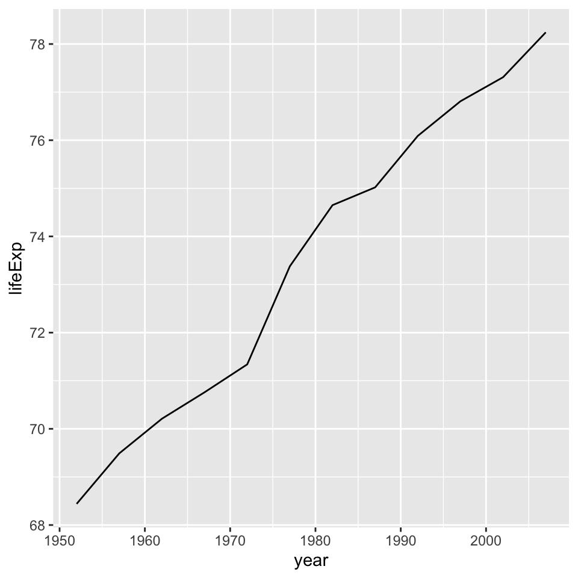

```r
# start with data and then
# filter to keep only United States data
# start a plot with x mapped to year and y mapped to life expectancy
# add a line geometrics
gapminder %>%
  filter(country == "United States") %>%
  ggplot(aes(x = year,
             y = lifeExp)) +
  geom_line()
```

# Messy datasets

Wickham (2014) lists the following most common problems found in messy datasets:

- Column headers are values, not variable names.
- Multiple variables are stored in one column.
- Variables are stored in both rows and columns.
- Multiple types of observational units are stored in the same table.
- A single observational unit is stored in multiple tables.

Each of the above will be illustrated with real data in the next sections, alongside with a solution on how to tidy the dataset. You can [download all data sets used in this document](https://d2l.arizona.edu/d2l/common/viewFile.d2lfile/Content/L2NvbnRlbnQvZW5mb3JjZWQvOTk4MDgwLTk5NS0yMjExLTFJU1RBMzIwMTAxMjAxL2RhdGFfZm9yX3dyYW5nbGluZy56aXA/data_for_wrangling.zip?ou=998080).

## Column headers are values, not variable names.

Here’s the first 10 rows of data from [Tucson’s Neighborhood Population Statistics](https://gisdata.tucsonaz.gov/datasets/neighborhood-population-statistics/data).

| neighborhood | 2010 | 2011 | 2012 | 2013 | 2014 | 2015 | 2016 | 2017 | 2018 |
| --- | --- | --- | --- | --- | --- | --- | --- | --- | --- |
| A Mountain | 3341 | 3340 | 3364 | 3360 | 3359 | 3337 | 3371 | 3408 | 3446 |
| Adelanto | 372 | 368 | 367 | 359 | 356 | 355 | 367 | 381 | 390 |
| Alvernon Heights | 304 | 301 | 300 | 299 | 309 | 316 | 323 | 318 | 318 |
| Amphi | 7432 | 7440 | 7401 | 7408 | 7290 | 7280 | 7252 | 7331 | 7394 |
| Armory Park | 1821 | 1851 | 1876 | 1867 | 1858 | 1860 | 1889 | 1915 | 1924 |
| Arroyo Chico | 2934 | 2951 | 2972 | 2961 | 2985 | 3001 | 3021 | 3026 | 3014 |
| Avondale | 1514 | 1509 | 1523 | 1537 | 1542 | 1541 | 1577 | 1603 | 1634 |
| Balboa Heights | 1389 | 1475 | 1531 | 1533 | 1482 | 1449 | 1436 | 1474 | 1504 |
| Barrio Anita | 392 | 391 | 399 | 402 | 410 | 403 | 404 | 403 | 393 |
| Barrio Blue Moon | 1008 | 1031 | 1038 | 1016 | 984 | 946 | 942 | 944 | 957 |

The three variables in this data are: neighborhood name, year, and population. However, most column headers are values for the `year variable` instead of actual variable name.

We fix this problem by pivoting (or turning) the table so that it’s a longer table (with only 3 columns, one for each variable).

```r
# create new pivoted (longer) data frame starting with original data and then
# pivoting all columns except neighborhood (-neighborhood) with column names
# set to "year" and values set to a column named "population"
tucson_pop_longer <- tucson_population_by_neighborhood %>%
  pivot_longer(cols = -neighborhood,
               names_to = "year",
               values_to = "population")

# inspect data
tucson_pop_longer %>%
  head(15)
```

```
## # A tibble: 15 × 3
##    neighborhood year  population
##    <chr>        <chr>      <dbl>
##  1 A Mountain   2010        3341
##  2 A Mountain   2011        3340
##  3 A Mountain   2012        3364
##  4 A Mountain   2013        3360
##  5 A Mountain   2014        3359
##  6 A Mountain   2015        3337
##  7 A Mountain   2016        3371
##  8 A Mountain   2017        3408
##  9 A Mountain   2018        3446
## 10 Adelanto     2010         372
## 11 Adelanto     2011         368
## 12 Adelanto     2012         367
## 13 Adelanto     2013         359
## 14 Adelanto     2014         356
## 15 Adelanto     2015         355
```

## Multiple variables are stored in one column.

Here’s the first 10 rows of data from [Tucson’s Neighborhood Race Demographics](https://gisdata.tucsonaz.gov/datasets/neighborhood-race-demographics/data), which has the same problem as the previous data set (i.e., column headers are values, not variable names).

| neighborhood | HISPASN_2019 | HISPPI_2019 | HISPOTH_2019 | HISPMLT_2019 | HWHITE_2010 | HBLACK_2010 | HAMERIND_2010 |
| --- | --- | --- | --- | --- | --- | --- | --- |
| A Mountain | 8 | 0 | 1226 | 114 | 1099 | 16 | 108 |
| Adelanto | 0 | 0 | 91 | 12 | 75 | 3 | 27 |
| Alvernon Heights | 2 | 0 | 67 | 13 | 100 | 4 | 2 |
| Amphi | 5 | 6 | 1571 | 233 | 1727 | 71 | 114 |
| Armory Park | 2 | 3 | 225 | 61 | 369 | 7 | 26 |
| Arroyo Chico | 4 | 2 | 504 | 115 | 841 | 5 | 28 |
| Avondale | 4 | 0 | 158 | 46 | 212 | 7 | 25 |
| Balboa Heights | 0 | 1 | 393 | 47 | 317 | 7 | 24 |
| Barrio Anita | 0 | 0 | 97 | 17 | 99 | 3 | 12 |
| Barrio Blue Moon | 2 | 1 | 226 | 26 | 219 | 12 | 29 |

We fix the first problem (i.e., column headers are values, not variable names) with `pivot_longer` (like in the previous section).

```r
# create new pivoted (longer) data frame starting with original data and then
# pivoting all columns except neighborhood (-neighborhood) with column names
# set to "year" and values set to a column named "population"
tucson_race_longer <- tucson_race_demographics %>%
  pivot_longer(cols = -neighborhood,
               names_to = "rec_year",
               values_to = "population")

# inspect data
tucson_race_longer %>%
  head(15)
```

```
## # A tibble: 15 × 3
##    neighborhood rec_year      population
##    <chr>        <chr>              <dbl>
##  1 A Mountain   WHITE_2019          1443
##  2 A Mountain   BLACK_2019           316
##  3 A Mountain   AMERIND_2019         227
##  4 A Mountain   ASIAN_2019            68
##  5 A Mountain   PACIFIC_2019           3
##  6 A Mountain   OTHRACE_2019        1236
##  7 A Mountain   RACE2UP_2019         155
##  8 A Mountain   HISPPOP_2019        2638
##  9 A Mountain   MINORITY_2019       3164
## 10 A Mountain   WHITE_2010          1451
## 11 A Mountain   BLACK_2010           318
## 12 A Mountain   AMERIND_2010         223
## 13 A Mountain   ASIAN_2010            62
## 14 A Mountain   PACIFIC_2010           3
## 15 A Mountain   OTHRACE_2010        1137
```

Now we turn to the second problem (i.e., multiple variables are stored in one column.). The `rec_year` column contains information about racial-ethnic-cultural (REC) identity of the population and the year the data was collected. We fix that problem using the `separate()` function.

```r
# overwrite tucson_race_longer data frame starting with tucson_race_longer and then
# separate the rec_year into the two variable columns rec and year
tucson_race_longer <- tucson_race_longer %>%
  separate(col = rec_year, into = c("rec", "year"))

# inspect data
tucson_race_longer %>%
  head(15)
```

```
## # A tibble: 15 × 4
##    neighborhood rec      year  population
##    <chr>        <chr>    <chr>      <dbl>
##  1 A Mountain   WHITE    2019        1443
##  2 A Mountain   BLACK    2019         316
##  3 A Mountain   AMERIND  2019         227
##  4 A Mountain   ASIAN    2019          68
##  5 A Mountain   PACIFIC  2019           3
##  6 A Mountain   OTHRACE  2019        1236
##  7 A Mountain   RACE2UP  2019         155
##  8 A Mountain   HISPPOP  2019        2638
##  9 A Mountain   MINORITY 2019        3164
## 10 A Mountain   WHITE    2010        1451
## 11 A Mountain   BLACK    2010         318
## 12 A Mountain   AMERIND  2010         223
## 13 A Mountain   ASIAN    2010          62
## 14 A Mountain   PACIFIC  2010           3
## 15 A Mountain   OTHRACE  2010        1137
```

## Variables are stored in both rows and columns

The table below shows the most complicated form of messy data (from https://www.meteoblue.com/en/weather/archive/export/tucson_united-states-of-america_5318313), with variables stored in both rows and columns.

| location | month | year | temp_type | 20 | 21 | 22 | 23 | 24 | 25 | 26 | 27 |
| --- | --- | --- | --- | --- | --- | --- | --- | --- | --- | --- | --- |
| Tucson | January | 2021 | max_temp | 67.54388 | 62.07189 | 66.73389 | 63.87189 | 50.13789 | 49.84989 | 44.55789 | 60.46989 |
| Tucson | January | 2021 | min_temp | 39.98589 | 50.98389 | 46.01589 | 37.89789 | 42.75789 | 34.49589 | 37.44789 | 29.50989 |

This data has month and year as variables (i.e., columns) and day as column names. Temperatures are values under each day (from January 20 2021 to January 27 2021). In addition, information about whether each value is a maximum or minimum temperature is store in a column called `temp_type`. Our actually variables for this are: location, date (divided into day, month, and year), minimum temperature, and maximum temperature.

First step is to `pivot_longer` to have day as a variable (i.e., one column).

```r
# overwrite tucson_race_longer data frame starting with tucson_race_longer and then
# pivot all columns that start with "2", set column name to "day"
tucson_seven_day_temps_longer <- tucson_seven_day_temps %>%
  pivot_longer(cols = starts_with("2"),
               names_to = "day")

# inspect data
tucson_seven_day_temps_longer
```

```
## # A tibble: 16 × 6
##    location month    year temp_type day   value
##    <chr>    <chr>   <dbl> <chr>     <chr> <dbl>
##  1 Tucson   January  2021 max_temp  20     67.5
##  2 Tucson   January  2021 max_temp  21     62.1
##  3 Tucson   January  2021 max_temp  22     66.7
##  4 Tucson   January  2021 max_temp  23     63.9
##  5 Tucson   January  2021 max_temp  24     50.1
##  6 Tucson   January  2021 max_temp  25     49.8
##  7 Tucson   January  2021 max_temp  26     44.6
##  8 Tucson   January  2021 max_temp  27     60.5
##  9 Tucson   January  2021 min_temp  20     40.0
## 10 Tucson   January  2021 min_temp  21     51.0
## 11 Tucson   January  2021 min_temp  22     46.0
## 12 Tucson   January  2021 min_temp  23     37.9
## 13 Tucson   January  2021 min_temp  24     42.8
## 14 Tucson   January  2021 min_temp  25     34.5
## 15 Tucson   January  2021 min_temp  26     37.4
## 16 Tucson   January  2021 min_temp  27     29.5
```

Then we `pivot_wider` to have two separate columns for our two numeric variables, i.e. minimum and maximum temperatures.

```r
# overwrite tucson_race_longer data frame starting with tucson_race_longer and then
# pivot temp_type into two columsn that take the values in the "value" column
tucson_seven_day_temps_wider <- tucson_seven_day_temps_longer %>%
  pivot_wider(names_from = temp_type,
              values_from = value)

# inspect data
tucson_seven_day_temps_wider
```

```
## # A tibble: 8 × 6
##   location month    year day   max_temp min_temp
##   <chr>    <chr>   <dbl> <chr>    <dbl>    <dbl>
## 1 Tucson   January  2021 20        67.5     40.0
## 2 Tucson   January  2021 21        62.1     51.0
## 3 Tucson   January  2021 22        66.7     46.0
## 4 Tucson   January  2021 23        63.9     37.9
## 5 Tucson   January  2021 24        50.1     42.8
## 6 Tucson   January  2021 25        49.8     34.5
## 7 Tucson   January  2021 26        44.6     37.4
## 8 Tucson   January  2021 27        60.5     29.5
```

Final touch is to create a `date` column that is an actual date data type.

```r
# create a new clean_tucson_seven_day_temps data frame with the results of
# mutation of new variable based on a paste of day, month, and year in our data
clean_tucson_seven_day_temps <- tucson_seven_day_temps_wider %>%
  mutate(date = parse_date(paste(month, day, year), "%B %d %Y"))

# inspect data
clean_tucson_seven_day_temps
```

```
## # A tibble: 8 × 7
##   location month    year day   max_temp min_temp date
##   <chr>    <chr>   <dbl> <chr>    <dbl>    <dbl> <date>
## 1 Tucson   January  2021 20        67.5     40.0 2021-01-20
## 2 Tucson   January  2021 21        62.1     51.0 2021-01-21
## 3 Tucson   January  2021 22        66.7     46.0 2021-01-22
## 4 Tucson   January  2021 23        63.9     37.9 2021-01-23
## 5 Tucson   January  2021 24        50.1     42.8 2021-01-24
## 6 Tucson   January  2021 25        49.8     34.5 2021-01-25
## 7 Tucson   January  2021 26        44.6     37.4 2021-01-26
## 8 Tucson   January  2021 27        60.5     29.5 2021-01-27
```

## Multiple types of observational units are stored in the same table

The idea here is that different types of observational units should be, in principle, stored in different data frames. The process of separating data that belongs to different observations onto different tables is related to the idea of database normalization (Wickham 2014). Normalization is just good practice, and it helps the data analyst understand the data better (and remove any inconsistencies). With that said, we often denormalize (i.e., merge tables with different types of observations) into one table for data analysis in R.

For example, the data below on rap artists’s song ratings across different years (from (Tidy Tuesday)[https://github.com/rfordatascience/tidytuesday/blob/master/data/2020/2020-04-14/readme.md]) includes observations on what position a rap song ranked in each year. But it also includes the name and gender of artist (which would belong to a separate table with artist demographics as the type of observations), which is then repeated many times because each artist shows up multiple times in the data. There is also information about the critic, their name, their role and country (which technically should be in a separate table).

| rank | title | artist | gender | year | critic_name | critic_rols | critic_country | critic_country2 |
| --- | --- | --- | --- | --- | --- | --- | --- | --- |
| 1 | Dear Mama | 2Pac | male | 1995 | Al Rocco | Artist | China | NA |
| 2 | Changes | 2Pac ft. Talent | male | 1998 | Al Rocco | Artist | China | NA |
| 1 | Dear Mama | 2Pac | male | 1995 | Allyson Toy | Critic | US | NA |
| 4 | I Get Around | 2Pac | male | 1993 | Allyson Toy | Critic | US | NA |
| 5 | I Get Around | 2Pac | male | 1993 | Andrew Barber | Fake Shore Drive | US | NA |
| 5 | Changes | 2Pac ft. Talent | male | 1998 | Andy Cohn | The FADER | US | NA |
| 4 | Ambitionz Az A Ridah | 2Pac | male | 1996 | Biba Adams | Critic | US | NA |
| 4 | Dear Mama | 2Pac | male | 1995 | Brian ‘Z’ Zisook | DJ Booth | US | NA |
| 3 | California Love | 2Pac ft. Dr Dre | male | 1996 | Fionn Birr | Critic | Germany | NA |
| 2 | Changes | 2Pac ft. Talent | male | 1998 | Georgette Cline | XXL | US | NA |

First we create a separate table for artists’ demographics.

```r
# create new artist_gender data frame with results of
# start with original data and then
# pull distinct combinations of artist and gender
artist_gender <- rap_artist_rankings %>%
  distinct(artist, gender)

# inspect data
artist_gender %>%
  head(10)
```

```
## # A tibble: 10 × 2
##    artist                                         gender
##    <chr>                                          <chr>
##  1 Public Enemy                                   male
##  2 Gza ft. Ghostface Killah & Killah Priest & RZA male
##  3 Run DMC                                        male
##  4 GLOBE & Whiz Kid                               male
##  5 O.C.                                           male
##  6 Slum Village                                   male
##  7 Stop The Violence Movement                     mixed
##  8 Salt-N-Pepa                                    female
##  9 2Pac                                           male
## 10 JAY-Z ft. UGK                                  male
```

Then create a separate table for song artist pairing information.

```r
# create new artist_gender data frame with results of
# start with original data and then
# pull distinct combinations of artist and gender
song_artist <- rap_artist_rankings %>%
  distinct(title, artist)

# create unique ID for song artist combination
# there is one repeated title
song_artist <- song_artist %>%
  mutate(song_id = c(1:nrow(song_artist)))

# inspect data
song_artist %>%
  head(10)
```

```
## # A tibble: 10 × 3
##    title                             artist                              song_id
##    <chr>                             <chr>                                 <int>
##  1 Terminator X To The Edge of Panic Public Enemy                              1
##  2 4th Chamber                       Gza ft. Ghostface Killah & Killah …       2
##  3 Peter Piper                       Run DMC                                   3
##  4 Play That Beat Mr DJ              GLOBE & Whiz Kid                          4
##  5 Time’s Up                         O.C.                                      5
##  6 Players                           Slum Village                              6
##  7 Self Destruction                  Stop The Violence Movement                7
##  8 Push It                           Salt-N-Pepa                               8
##  9 Ambitionz Az A Ridah              2Pac                                      9
## 10 Big Pimpin'                       JAY-Z ft. UGK                            10
```

Let’s ensure that song ID (variable just created for unique song title + artist combination) in added to the original data frame.

```r
# add song ID to the original data frame
rap_artist_rankings <- left_join(rap_artist_rankings,
                                 song_artist)
```

We also need to create a separate table with critic information.

```r
# create new critic_info data frame with results of
# start with original data and then
# pull distinct combinations of artist and gender
critic_info <- rap_artist_rankings %>%
  distinct(critic_name, critic_rols, critic_country, critic_country2)

# inspect data
critic_info %>%
  head(10)
```

```
## # A tibble: 10 × 4
##    critic_name            critic_rols      critic_country critic_country2
##    <chr>                  <chr>            <chr>          <chr>
##  1 Joseph Abajian         Fat Beats        US             <NA>
##  2 Biba Adams             Critic           US             <NA>
##  3 Dart Adams             Critic           US             <NA>
##  4 Insanul Ahmed          Genius           US             <NA>
##  5 Joey Akan              Critic           Nigeria        <NA>
##  6 Antonio ‘Rolo’ Alarcon Critic           US             <NA>
##  7 Ivie Ani               Critic           US             <NA>
##  8 Andrew Barber          Fake Shore Drive US             <NA>
##  9 Fionn Birr             Critic           Germany        <NA>
## 10 Davide Bortot          Critic           Germany        <NA>
```

Finally, we create a new data frame that keeps only variables that are directly related the ranking of rap artists. First we add song ID to the original data frame. Each song has a rank every year, given by a critic (we can keep `critic_name` as a unique key for critic because there are no repeated critic names).

```r
# create new data frame (rap_artist_ranking_clean) with info related to song ranking only
rap_artist_ranking_clean <- rap_artist_rankings %>%
  select(song_id, rank, year, critic_name)

# inspect data
rap_artist_ranking_clean %>%
  head()
```

```
## # A tibble: 6 × 4
##   song_id  rank  year critic_name
##     <int> <dbl> <dbl> <chr>
## 1       1     1  1998 Joseph Abajian
## 2       2     2  1995 Joseph Abajian
## 3       3     3  1986 Joseph Abajian
## 4       4     4  2001 Joseph Abajian
## 5       5     5  1994 Joseph Abajian
## 6       6     1  1997 Biba Adams
```

## A single observational unit is stored in multiple tables

While having multiple types of observational units are stored in the same table (previous section) is not an issue for most data analysis in R, having a single observational unit store in multiple tables can hinder analysis. That usually happens when your data is split into different files, and the file name indicates some important information about the data, such as year.

Below is an example of that, with [US baby names data from Kaggle](https://www.kaggle.com/zerryberry/us-baby-names). This is just a demonstration with two files. In a real analysis, you would need a function and a for loop to load all files. But let’s load two files, making sure the variable `year` is added through a `mutate()` so we don’t lose that information once we combine the data.

```r
# read data in
# year 2010
us_baby_names_2010 <- read_csv("data/us_baby_names/yob2010.txt",
                               col_names = FALSE,
                               col_types = list(col_character(),
                                                col_character(),
                                                col_double())) %>%
  dplyr::rename(name = X1,
         gender = X2,
         count = X3) %>%
  mutate(year = 2010)

# year 2009
us_baby_names_2009 <- read_csv("data/us_baby_names/yob2009.txt",
                               col_names = FALSE,
                               col_types = list(col_character(),
                                                col_character(),
                                                col_double())) %>%
  dplyr::rename(name = X1,
         gender = X2,
         count = X3) %>%
  mutate(year = 2009)

# inspect data
us_baby_names_2010 %>%
  head()
```

```
## # A tibble: 6 × 4
##   name     gender count  year
##   <chr>    <chr>  <dbl> <dbl>
## 1 Isabella F      22731  2010
## 2 Sophia   F      20477  2010
## 3 Emma     F      17179  2010
## 4 Olivia   F      16860  2010
## 5 Ava      F      15300  2010
## 6 Emily    F      14172  2010
```

```r
us_baby_names_2009 %>%
  head()
```

```
## # A tibble: 6 × 4
##   name     gender count  year
##   <chr>    <chr>  <dbl> <dbl>
## 1 Isabella F      22222  2009
## 2 Emma     F      17830  2009
## 3 Olivia   F      17374  2009
## 4 Sophia   F      16869  2009
## 5 Ava      F      15826  2009
## 6 Emily    F      15295  2009
```

Once we have all the individual data files, we can combine them using the `bind_rows()` function.

```r
# combine all data into one
us_baby_names <- bind_rows(us_baby_names_2009,
                           us_baby_names_2010)

# inspect data
us_baby_names %>%
  arrange(-count) %>%
  head(10)
```

```
## # A tibble: 10 × 4
##    name      gender count  year
##    <chr>     <chr>  <dbl> <dbl>
##  1 Isabella  F      22731  2010
##  2 Isabella  F      22222  2009
##  3 Jacob     M      21875  2010
##  4 Jacob     M      21036  2009
##  5 Sophia    F      20477  2010
##  6 Ethan     M      19783  2009
##  7 Michael   M      18822  2009
##  8 Alexander M      18175  2009
##  9 Ethan     M      17866  2010
## 10 William   M      17852  2009
```

# Extra Resource

- [R for Data Science, Chapter 12 Tidy data](https://r4ds.had.co.nz/tidy-data.html)

# Reference

Wickham, Hadley. 2014. “Tidy Data.” *Journal of Statistical Software* 59 (10): 1–23.